# DEGAS: Spatial transcriptomic analysis of pancreatic cancer

Justin Louis Couetil

March 03, 2022

# Load required packages

```r
library(DEGAS)
library(Rtsne)
library(ggplot2)
library(here)
library(reticulate)
library(tidyverse)
library(magrittr)
```

Trying to visualize ST data

# Spatial Data

To note (again):

I added “ID” into the stDat.txt file, because they were lacking a title. This meant that they did not read in properly…

This is where the data from Moncada’s publication can be found:

https://www.ncbi.nlm.nih.gov/geo/query/acc.cgi?acc=GSE111672

## Reading in ST gene data…

```r
# reading in
stDat <- readr::read_csv(here("data/PDAC/data/genetic/spatial/stDat.txt"))
stDat <- stDat %>% mutate_all(as.character)


# Now, I want the columns to be genes, and the rows to be the ST regions (i.e. ST1, ST2 ... ST428)
test <- slice(stDat, 1)

test[1,] <- colnames(test) %>% as.matrix() %>% t()

# transpose the data
stDat <- rbind(test, stDat) %>% t() %>% as_tibble()
stDat <- as_tibble(stDat)

# make rename the columns as the gene names.

colnames(stDat) <- slice(stDat, 1)
stDat <- slice(stDat, -1)

# Success! Now the the data table is flipped, with the genes as columns!

# Finally, correcting the data types:
# Column [,1] is the ID field. So that's a character! All the others can be integers, since there are no decimals.
stDat <- stDat %>% mutate_at(vars(2:ncol(stDat)), as.integer)
```

## Normalization

Using the preprocessCounts() function from DEGAS.

```r
# the first column is the ST spot ID.

stDat <- cbind(stDat[1], t(preprocessCounts(stDat[-1]))) %>% as_tibble()
```

## Reading in ST location data

the original stLab.txt file was edited by me. I added “ID” to the beginning of the first row. Otherwise there was a mismatch in the number of entries and the number of columns:

**“ID”** “coord1” “coord2” “coord1.norm” “coord2.norm” “spotID” “histology” “histology_color” “ST1” 10 10 0.567142857142857 0.201538461538462 “ST1” “Interstitium” “green”

```r
stLab <- readr::read_delim(here::here("data/PDAC/data/genetic/spatial/stLab.txt"), delim = " ")
```

Here is the slide, pathologist annotations for tissue are from Moncada et al, Nature Biotechnology, 2020, Figure 4, Panel A.

Based on their publication, these are the annotations for the little plot below. (**note the colors below are not the same as they are in their pub.**, but they are the same annotations!)

- black = cancer
- blue = normal pancreatic tissue
- red = duct epithelium
- green = Interstitium/stroma

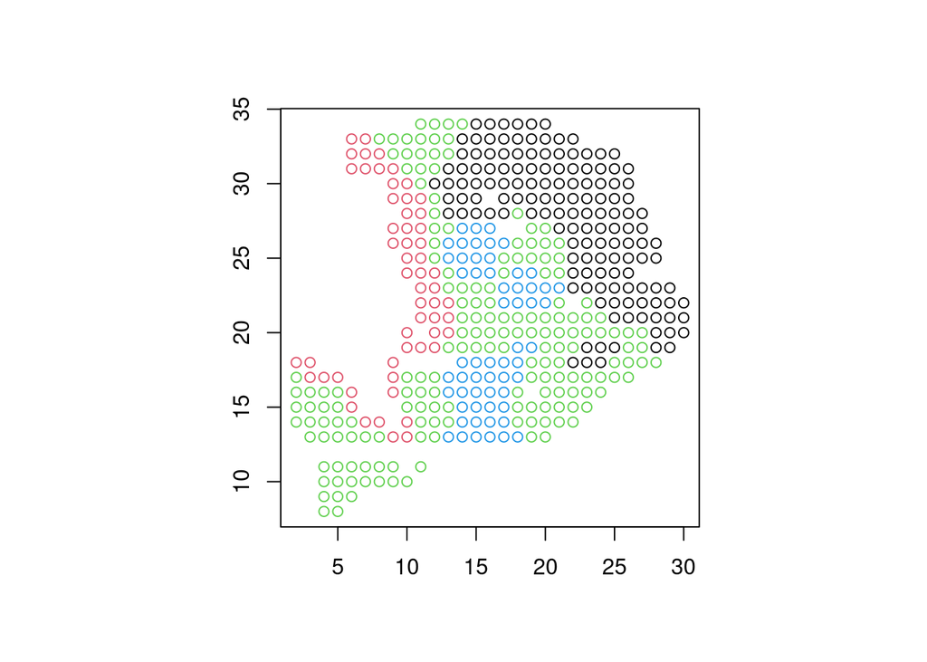

```r
par(pty = "s")
plot(x = stLab$coord1, y = stLab$coord2, xlab = '', ylab = '', col = as.factor(stLab$histology))
```

And here, I’ve pasted in their image, with the previous plot roughly overlaid.

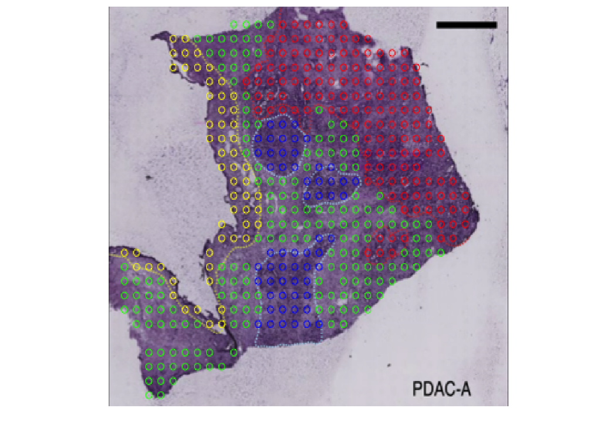

```r
# Import the image
img <- png::readPNG(here::here("data/PDAC/data/genetic/spatial", "PDACA1_labelled_edited.png"))

# Plot with background image
ggplot(stLab, aes(x = stLab$coord1, y = stLab$coord2)) +
  ggpubr::background_image(img) +
  #geom_point() +
  coord_fixed(ratio = 1) +
  labs(x = "", y = '')
```

One-hot encoding the labels.

[cell#, HISTO_type1] ID1 1, 0, 0, 0 ID2 0, 1, 0, 0 ID3 0, 0, 0, 1

```r
stLab <- stLab %>% mutate(histology = str_replace_all(histology, pattern = " ", replacement = "_"))
```

```r
stLab <- stLab %>% pivot_wider(id_cols = ID, names_from = histology, values_from = histology)
```

There we go, done!

```r
stLab <-
  stLab %>%
  mutate_at(vars(2:ncol(stLab)), gsub, pattern = ".*", replacement = 1) %>%
  mutate_at(vars(2:ncol(stLab)), replace_na, replace = 0) %>%
  mutate_at(vars(2:ncol(stLab)), as.integer) # I added this line recently, make sure it changes the data type from chr to int.
```

# Clinical Data

## Survival

https://portal.gdc.cancer.gov/projects/TCGA-PAAD

```r
patLab <- read.delim(here("data/PDAC/data/clinical/PAAD.clin.merged.picked.txt"), header=FALSE)

patLab <- patLab %>% t() %>% as_tibble()
```

```r
colnames(patLab) <- slice(patLab, 1)

patLab <- slice(patLab, -1)
```

There are no entries with both days_to_death AND days_to_last_followup. So it seems there are no errors to worry about and we can conclude the Relapse Free Survival Time for each patient.

```r
patLab <- patLab %>% select(TCGA_ref = "Hybridization REF",days_to_death, days_to_last_followup)
```

Ok! Here we go, the patLab object is set up. The only thing to do before this is ready for DEGAS is to remove the TCGA_ref.

```r
holder <- patLab %>% filter(is.na(days_to_death))
holder <- holder %>% mutate(RFS_Time = days_to_last_followup, RFS_Event = 0) %>% select(-c('days_to_death', 'days_to_last_followup'))

patLab <- patLab %>% filter(is.na(days_to_last_followup)) %>% mutate(RFS_Time = days_to_death, RFS_Event = 1) %>% select(-c('days_to_death', 'days_to_last_followup')) %>% full_join(holder)
patLab$RFS_Time <- patLab$RFS_Time %>% as.numeric()
```

## RNA

http://firebrowse.org/ –> PAAD mRNASeq Archives –> illuminahiseq_rnaseqv2-RSEM_genes_normalized –> this file shows the reads on genes:

Following the same procedure as above to read in the data.

```r
patDat <- read.delim(here::here('data/PDAC/data/clinical/gdac.broadinstitute.org_PAAD.Merge_rnaseqv2__illuminahiseq_rnaseqv2__unc_edu__Level_3__RSEM_genes_normalized__data.Level_3.2016012800.0.0/PAAD.rnaseqv2__illuminahiseq_rnaseqv2__unc_edu__Level_3__RSEM_genes_normalized__data.data.txt'), header=FALSE)

patDat <- patDat %>% t() %>% as_tibble()
```

```r
colnames(patDat) <- slice(patDat, 1)

patDat <- slice(patDat, -1)
```

So, now I see the problem is that the colnames have “|” and then their NCBI ID after that. I just want the gene names.

Note that there are some genes with duplicate names! I just get rid of them below.

```r
patDat <- patDat %>% select(-c(`SLC35E2|728661`,`SLC35E2|9906`))
```

```r
colnames(patDat) <- gsub(pattern = "\\|.*",replacement = "", colnames(patDat)) # this thing is wrong i think.
```

Getting rid of hypothetical loci (they begin with “?”)

```r
cols_to_delete <- stringr::str_detect(colnames(patDat), pattern = "\\?") %>% which() #%>% sapply(isTRUE)
patDat <- patDat %>% select(-cols_to_delete)
```

```
## Note: Using an external vector in selections is ambiguous.
## ℹ Use `all_of(cols_to_delete)` instead of `cols_to_delete` to silence this message.
## ℹ See <https://tidyselect.r-lib.org/reference/faq-external-vector.html>.
```

Now to correct the data type

```r
patDat <- patDat %>% mutate(across(.cols = 3:ncol(patDat),.fns = as.numeric))
```

…and finally, normalizing the data with the DEGAS preprocessCounts() function.

```r
patDat <- cbind(patDat[1:2], t(preprocessCounts(patDat[-c(1,2)]))) %>% as_tibble()
```

There aren’t the same number of entries for the survival data as the patient transcriptomic data!

```r
nrow(patDat)
```

```
## [1] 183
```

```r
nrow(patLab)
```

```
## [1] 185
```

```r
patDat <- patDat %>% mutate(`Hybridization REF` = gsub(tolower(`Hybridization REF`), pattern = "-[0-9][0-9]a.*", replacement = ""))
```

This is where I get rid of the mismatches between # of entries.

```r
colnames(patDat)[1] <- "TCGA_hybr_ref"
colnames(patLab)[1] <- "TCGA_hybr_ref"
```

```r
# patDat <- patDat[match(patDat$TCGA_hybr_ref, patLab$TCGA_hybr_ref),]
# patLab[complete.cases(patLab[match(patLab$TCGA_hybr_ref, patDat$TCGA_hybr_ref, by),]),]

patLab <- patLab %>% inner_join(patDat %>% select('TCGA_hybr_ref'), by = "TCGA_hybr_ref")
```

# DEGAS

Just look at the intersection of genes between ST (stDat) data and TCGA (patDat).

```r
overlapping_genes <- colnames(patDat)[match(colnames(stDat), colnames(patDat))]
overlapping_genes <- overlapping_genes[!is.na(overlapping_genes)]

patDat <- patDat %>% select(all_of(overlapping_genes)) # this also gets rid of the ID column...
stDat <- stDat %>% select(all_of(overlapping_genes)) # this also gets rid of the ID column...
```

Have to get rid of NA, turn them to 0’s.

```r
# # getwd()
stDat <- stDat %>% mutate_all(replace_na, replace = 0)
patDat <- patDat %>% mutate_all(replace_na, replace = 0)
```

## Initialize DEGAS framework

```r
path.data = ''
path.result = ''
initDEGAS()
tmpDir = paste0(path.result, 'tmp/')
```

```r
stLab <- stLab %>% select(-ID)
```